# Airbnb in NYC with SparkR and Sparkling water

Dominik Klepl

2/6/2020

## Connect to Spark

Load required libraries

Launch Spark session and create Spark context (sc)

```r
sc = spark_connect(master = "local", version = "2.2.1")
```

Create H2O context

```r
#hc = H2OContext.getOrCreate(sc)
```

Open H2O (Sparkling water) UI

```r
#hc$openFlow()
```

### Load data

Our dataset is a csv file. Now we’ll load into spark.

```r
#path to dataset
DATA_PATH = "data/AB_NYC_2019.csv"
VISUALIZATIONS = "documentation/figures"
data = spark_read_csv(sc = sc, name = "data", path = DATA_PATH)
class(data)
```

```
## [1] "tbl_spark" "tbl_sql"   "tbl_lazy"  "tbl"
```

Let’s look at the data

```r
cat("The dataset has", sdf_nrow(data), "datapoints","\nand", sdf_ncol(data), "features.")
```

```
## The dataset has 49079 datapoints
## and 16 features.
```

What columns do we have?

```r
colnames(data)
```

```
##  [1] "id"                             "name"
##  [3] "host_id"                        "host_name"
##  [5] "neighbourhood_group"            "neighbourhood"
##  [7] "latitude"                       "longitude"
##  [9] "room_type"                      "price"
## [11] "minimum_nights"                 "number_of_reviews"
## [13] "last_review"                    "reviews_per_month"
## [15] "calculated_host_listings_count" "availability_365"
```

Some of these columns won’t be very useful in the further analysis so we exclude them.

```r
data = data %>%
  select(-c(id, host_name))
```

## Missing values

First, we’ll deal with the missing values and try to avoid dropping them as much as possible.

```r
(missing_values = data %>%
  mutate_all(is.na) %>%
  mutate_all(as.numeric) %>%
  summarise_all(sum) %>%
  collect() %>%
  t() %>%
  as.data.frame())
```

```
##                                   V1
## name                              32
## host_id                          185
## neighbourhood_group              185
## neighbourhood                    185
## latitude                         185
## longitude                        185
## room_type                        185
## price                            185
## minimum_nights                   185
## number_of_reviews                205
## last_review                    10234
## reviews_per_month              10215
## calculated_host_listings_count   187
## availability_365                 342
```

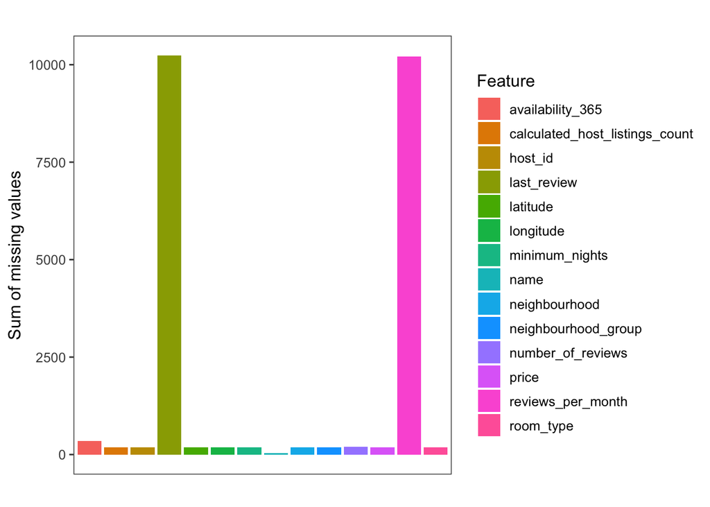

```r
colnames(missing_values) = "NAs"
missing_values$Feature = rownames(missing_values)
rownames(missing_values) = NULL

missing_values = missing_values %>% filter(NAs !=0)

(NA_plot = ggplot(missing_values, aes(x = Feature, y = NAs, fill=Feature))+
  geom_col()+
  theme_few()+
  theme(axis.text.x = element_blank(),
        axis.ticks.x = element_blank())+
  labs(title = "",
       x = "",
       y = "Sum of missing values"))
```

```r
ggsave(paste0(VISUALIZATIONS,"/missing_values.png"), NA_plot, width = 7, height = 4)
```

Most missing values are in last_review and reviews_per_month. This probably happens when a listing has no reviews yet. Let’s test that hypothesis.

```r
#how many number_of_reviews==0 have NA in reviews_per_month
NA_test = data %>%
  select(number_of_reviews, reviews_per_month, last_review) %>%
  filter(number_of_reviews==0) %>%
  mutate(na_month = as.character(is.na(reviews_per_month))) %>%
  mutate(na_last = as.character(is.na(last_review)))

NA_test %>%
  group_by(na_month) %>%
  summarise(count = n())
```

```
## # Source: spark<?> [?? x 2]
##   na_month count
##   <chr>    <dbl>
## 1 true     10029
```

```r
NA_test %>%
  group_by(na_last) %>%
  summarise(count = n())
```

```
## # Source: spark<?> [?? x 2]
##   na_last count
##   <chr>   <dbl>
## 1 true    10029
```

Most of NAs in last_review and reviews_per_month were indeed the result of having no reviews yet. We can therefore replace these NAs with 0. There are also a few missing values in name and host_id, we’ll replace these with “unknown” as there might be a use for that column. Since host_id and host_name contain the same information, we’ll exclude the host_name.

```r
data = data %>%
  #replace with 0
  mutate(last_review = ifelse(is.na(last_review), 0, last_review)) %>%
  #replace with 0
  mutate(reviews_per_month = ifelse(is.na(reviews_per_month), 0, reviews_per_month)) %>%
  #replace with unknown
  mutate(name = ifelse(is.na(name), "Unknown", name)) %>%
  #replace with unknown
  mutate(host_id = ifelse(is.na(host_id), "Unknown", host_id))
```

Now there is only a few missing values left (around 300), we’ll simply exclude those datapoints.

```r
data = na.omit(data)
```

```
## * Dropped 343 rows with 'na.omit' (49079 => 48736)
```

## Categorical features

Make sure that the categories are normalized (e.g. all lowercase)

#### Neighbourhood group

```r
data %>%
  distinct(neighbourhood_group) %>%
  collect()
```

```
## # A tibble: 12 x 1
##    neighbourhood_group
##    <chr>
##  1 Staten Island
##  2 194716858
##  3 Brooklyn
##  4 Manhattan
##  5 Seth
##  6 Krista
##  7 Evelyn
##  8 Queens
##  9 William Hakan
## 10 D
## 11 Bronx
## 12 Carmen
```

```r
#there are some strange categories - some number and "D"
#inspect how many listings there are per neighbourhood group
neighbourhoods_groups = data %>%
  group_by(neighbourhood_group) %>%
  summarise(count = n()) %>%
  filter(count > 1) %>%
  collect()

#there are several neighbourhoods with single listing, let's remove those - create list of neighbourhoods to keep, we'll filter later, all at once
neighbourhood_gr_keep = neighbourhoods_groups$neighbourhood_group
```

#### Neighbourhood

```r
data %>%
  distinct(neighbourhood) %>%
  arrange(neighbourhood) %>% #order alphabetically
  mutate(neighbourhood = tolower(neighbourhood)) %>%
  collect()
```

```
## # A tibble: 225 x 1
##    neighbourhood
##    <chr>
##  1 2
##  2 allerton
##  3 arden heights
##  4 arrochar
##  5 arverne
##  6 astoria
##  7 bath beach
##  8 battery park city
##  9 bay ridge
## 10 bay terrace
## # … with 215 more rows
```

```r
#there's many neighbourhoods but again we can see some strange names and it's also possible there will be neighbourhoods with very low number of listings - let's exclude all that have less than 50
(neighbourhoods = data %>%
  group_by(neighbourhood) %>%
  summarise(count = n()) %>%
  filter(count >= 50) %>%
  arrange(desc(count)) %>%
  collect())
```

```
## # A tibble: 98 x 2
##    neighbourhood      count
##    <chr>              <dbl>
##  1 Williamsburg        3914
##  2 Bedford-Stuyvesant  3705
##  3 Harlem              2642
##  4 Bushwick            2460
##  5 Upper West Side     1968
##  6 Hell's Kitchen      1951
##  7 East Village        1849
##  8 Upper East Side     1791
##  9 Crown Heights       1560
## 10 Midtown             1541
## # … with 88 more rows
```

```r
#that leaves us with 98 neighbourhoods - let's save those, filter later
neighbourhood_keep = neighbourhoods$neighbourhood
```

#### Room type

```r
data %>%
  distinct(room_type)
```

```
## # Source: spark<?> [?? x 1]
##    room_type
##    <chr>
##  1 40.57453
##  2 -74.00244
##  3 Private room
##  4 Shared room
##  5 Howard
##  6 -73.94861
##  7 Entire home/apt
##  8 -73.95777
##  9 -73.95179
## 10 -73.90783
```

```r
#again, we see strange values, let's get only those that have more than 1 listing
(room_types = data %>%
  group_by(room_type) %>%
  summarise(count = n()) %>%
  filter(count > 1) %>%
  collect())
```

```
## # A tibble: 3 x 2
##   room_type       count
##   <chr>           <dbl>
## 1 Private room    22226
## 2 Shared room      1158
## 3 Entire home/apt 25345
```

```r
#let's get a vector of room_types to keep
room_keep = room_types$room_type
```

#### Filter categories

```r
data_clean = data %>%
  filter(neighbourhood_group %in% neighbourhood_gr_keep) %>%
  filter(neighbourhood %in% neighbourhood_keep) %>%
  filter(room_type %in% room_keep)

sdf_nrow(data_clean)
```

```
## [1] 46942
```

## Save to csv

Normally, we’d save the data back to HDFS (or any other distributed storage), however we know that this dataset can fit in the memory, so we’ll simply collect it from the workers and write it to csv the “classic” way. Sorry.

```r
write = collect(data_clean)
write.csv(write, "data/cleaned_data.csv")
```